# spsur user guide

The user guide

Román Mínguez, University of Castilla-La Mancha (Spain)

Fernando A. López, Technical University of Cartagena (Spain)

Jesús Mur, University of Zaragoza, (Spain)

2025-09-02

Load packages:

```r
library(spsur)
library(sf)
library(dplyr)
```

# 1 Introduction

The purpose of this vignette is to show the functionalities of the new R-package **spsur** (Mínguez, López, and Mur 2022; López, Mı́nguez, and Mur 2020). In the vignette the reader will find information about the following aspects:

- Description of the dataset NCOVR, employed to illustrate the use of the package.
- Estimation of SUR models without spatial effects (the so called SUR-SIM models).
- Testing for various forms of spatial autocorrelation in the SUR-SIM model.
- In case of misspecification of the SUR-SIM model, estimation of SUR models with spatial effects, by ML or IV.
- Misspecification tests in a estimated spatial SUR model.
- Measures of spatial interaction for a spatial SUR model, the so-called Direct/Indirect/Total effects.
- Estimation of a spatial SUR panel data model, with 1 equation and several cross-sections.
- Generation of random data sets with the required spatial SUR structure.

# 2 The data set NCOVR

Throughout the vignette we use the dataset NCOVR (National Consortium on Violence Research) to illustrate the capabilities of the package. The same data were employed by Baller et al. (2001) to analyze the incidence of homicides rates in the US counties. The dataset can be freely dowloaded from **https://geodacenter.github.io/data-and-lab/ncovr/**

There are three dimensions to consider in a SUR model: N, number of individuals, Tm, number of time periods and G, number of equations. Typically, in a spatial setting N will be large and Tm moderate with a small number of equations. NCOVR fits very well with the above description: it contains 3085 spatial units (counties), for 4 different cross-sections (1960, 1970, 1980, 1990) and 69 variables. According to Baller et al. (2001), the main variables of interest are:

- HR: homicide rate per 100000 inhabitants
- RD: resource deprivation
- PS: population structure
- MA: median age
- DV: divorce rate (% males over 14 divorced)
- UE: unemployment rate
- SOUTH: dummy variable for Southern counties (South = 1)

**spsur** deals with datasets from large to very small, especially in what respects to the number of spatial units. In this case, the dimensions of NCOVR make it a large dataset.

First, we can read the NCOVR dataset as a simple feature (sf) object (named NCOVR.sf),

```r
data(NCOVR, package = "spsur")
```

The first three observations in NCOVR appear below:

```r
NCOVR <- st_drop_geometry(NCOVR.sf)
knitr::kable(
  head((NCOVR[1:3, 1:6])),
  caption = 'First observations of NCOVR dataset' )
```

| NAME | STATE_NAME | FIPS | SOUTH | HR60 | HR70 |
| --- | --- | --- | --- | --- | --- |
| Lake of the Woods | Minnesota | 27077 | 0 | 0.000000 | 0.000000 |
| Ferry | Washington | 53019 | 0 | 0.000000 | 0.000000 |
| Stevens | Washington | 53065 | 0 | 1.863863 | 1.915158 |

Whereas the geometry of the USA counties is shown in Figure 1:

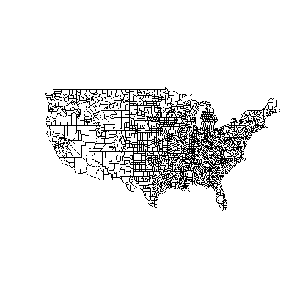

Figure 1: Geometry of the USA counties

```r
plot(st_geometry(NCOVR.sf))
```

Following Baller et al. (2001), we consider a **W** matrix based on the criterion of 10 nearest-neighbourhood, which is inmediate to obtain using the **spdep** package, Bivand, Pebesma, and Gómez-Rubio (2013). The resulting weighting matrix can be obtained using *lwncovr* object. Note that this matrix is non-symmetric.

```r
# Obtain coordinates of centroids
co <- sf::st_coordinates(sf::st_centroid(NCOVR.sf))
lwncovr <- spdep::nb2listw(spdep::knn2nb(spdep::knearneigh(co, k = 10,longlat = TRUE)))
```

Figure 2 shows the Quantile map for the Homicide Rate in the year 1960. Apparently there exist a strong structure of positive spatial autocorrelation. We observe a big cluster of the type High-High in the South East and South West counties, which evolves to Low-Low as we move to the North.

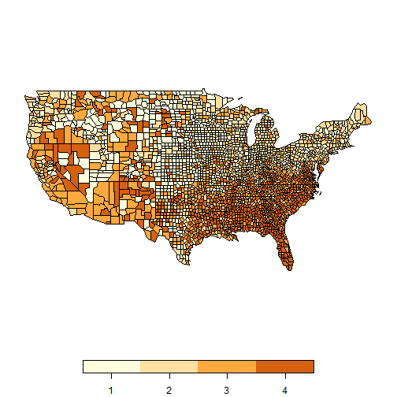

Figure 2: Quantile Map; Variable HR60

```r
q <- quantile(NCOVR.sf$HR60)
NCOVR.sf$qm <- (NCOVR.sf$HR60 > q[2]) + (NCOVR.sf$HR60 > q[3]) +(NCOVR.sf$HR60 >= q[4]) + 1
plot(NCOVR.sf["qm"], pal = c("#FFFEDE","#FFDFA2", "#FFA93F", "#D5610D"),
     main = "")
```

Baller et al. (2001) specify a single linear model to explain the case of HR in the year 1960 with the results shown in the Table below, identical to those in Table 1 of Baller et al. (2001).

$$\begin{equation}
HR_{60} = \beta_{0}+\beta_{1}RD_{60}+\beta_{2}PS_{60}+\beta_{3}MA_{60}+\beta_{4}DV_{60} +\beta_{5}UE_{60} +\beta_{6}SOUTH+\epsilon_{60}
\tag{2.1}
\end{equation}$$

```r
formula_60 <- HR60 ~ RD60 + PS60 + MA60 + DV60 + UE60 + SOUTH
lm_60 <- lm(formula = formula_60, data = NCOVR.sf)
summary(lm_60)
```

```
#>
#> Call:
#> lm(formula = formula_60, data = NCOVR.sf)
#>
#> Residuals:
#>     Min      1Q  Median      3Q     Max
#> -14.026  -2.217  -0.635   1.393  88.312
#>
#> Coefficients:
#>             Estimate Std. Error t value Pr(>|t|)
#> (Intercept)  8.12591    0.63465  12.804  < 2e-16 ***
#> RD60         1.79824    0.12341  14.571  < 2e-16 ***
#> PS60         0.35871    0.09216   3.892 0.000101 ***
#> MA60        -0.23047    0.01932 -11.931  < 2e-16 ***
#> DV60         1.16002    0.09483  12.233  < 2e-16 ***
#> UE60        -0.06195    0.03515  -1.762 0.078138 .
#> SOUTH        2.63862    0.23325  11.312  < 2e-16 ***
#> ---
#> Signif. codes:  0 '***' 0.001 '**' 0.01 '*' 0.05 '.' 0.1 ' ' 1
#>
#> Residual standard error: 4.743 on 3078 degrees of freedom
#> Multiple R-squared:  0.2966, Adjusted R-squared:  0.2952
#> F-statistic: 216.3 on 6 and 3078 DF,  p-value: < 2.2e-16
```

Figure 2 points to the existence of cross-sectional dependence in the spatial distribution of HR60 but the model in (2.1) does not contain elements of spatial interaction. The consequence is a scattermap of the LS residuals, Figure 3, with a strong structure of clusters, similar to that of HR60 in Figure 2.

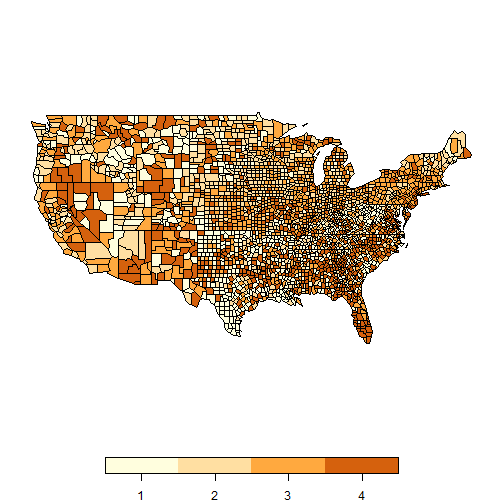

Figure 3: Quantile Map of LS residuals

```r
q <- quantile(lm_60$residuals)
NCOVR.sf$qmr <- (lm_60$residuals > q[2]) + (lm_60$residuals > q[3]) + (lm_60$residuals >= q[4]) + 1
plot(NCOVR.sf["qmr"], pal = c("#FFFEDE","#FFDFA2", "#FFA93F", "#D5610D"), main = "")
```

The battery of LM tests for omitted spatial structure, supplied by **spdep** Bivand, Pebesma, and Gómez-Rubio (2013), confirms the misspecification of (2.1). According to these results, the most adequate specification is a spatial lag model. Similar results are obtained for the years 1970, 1980 and 1990, which we omit for reasons of space.

```r
print(spdep::lm.LMtests(model=lm_60,listw = lwncovr,test="all"))
```

```
#>
#>  Lagrange multiplier diagnostics for spatial dependence
#>
#> data:
#> model: lm(formula = formula_60, data = NCOVR.sf)
#> weights: lwncovr
#>
#> LMerr = 208.12, df = 1, p-value < 2.2e-16
#>
#>
#>  Lagrange multiplier diagnostics for spatial dependence
#>
#> data:
#> model: lm(formula = formula_60, data = NCOVR.sf)
#> weights: lwncovr
#>
#> LMlag = 232.1, df = 1, p-value < 2.2e-16
#>
#>
#>  Lagrange multiplier diagnostics for spatial dependence
#>
#> data:
#> model: lm(formula = formula_60, data = NCOVR.sf)
#> weights: lwncovr
#>
#> RLMerr = 1.1565, df = 1, p-value = 0.2822
#>
#>
#>  Lagrange multiplier diagnostics for spatial dependence
#>
#> data:
#> model: lm(formula = formula_60, data = NCOVR.sf)
#> weights: lwncovr
#>
#> RLMlag = 25.138, df = 1, p-value = 5.337e-07
#>
#>
#>  Lagrange multiplier diagnostics for spatial dependence
#>
#> data:
#> model: lm(formula = formula_60, data = NCOVR.sf)
#> weights: lwncovr
#>
#> SARMA = 233.25, df = 2, p-value < 2.2e-16
```

The previous discussion is an example of the traditional approach in spatial econometrics, where we process the data cross-section by cross-section, perhaps in a panel framework. We stop here this analysis in favour of a multivariate approach using SUR models, which is the purpose of **spsur**.

# 3 A single SUR model

We begin by introducing dependence in the errors of the same county across time, as in expression (3.1) below. Note that time dependence in the errors of different counties is not allowed. To simplify we consider only two cross-sections, 1960 and 1970.

$$\begin{equation}
HR_{60} = \beta_{10}+\beta_{11}RD_{60}+\beta_{12}PS_{60}+\beta_{13}MA_{60}+\beta_{14}DV_{60} +\beta_{15}UE_{60} +\beta_{16}SOUTH+\epsilon_{60}\\
HR_{70} = \beta_{20}+\beta_{21}RD_{70}+\beta_{22}PS_{70}+\beta_{23}MA_{70}+\beta_{24}DV_{70} +\beta_{25}UE_{70} +\beta_{26}SOUTH+\epsilon_{70} \\
Corr(\epsilon_{60},\epsilon_{70}) \neq 0 \\
\tag{3.1}
\end{equation}$$

The package **Formula** is used to build the model in **spsur**

```r
formula_sur <- HR60 | HR70 ~ RD60 + PS60 + MA60 + DV60 + UE60 + SOUTH |  RD70 + PS70 + MA70 + DV70 + UE70 + SOUTH
```

The function `spsurml()` estimates a pure SUR model without spatial effects, which we call SUR-SIM. The *key argument* to estimate this model is *type = “sim”*, which declares the type of spatial specification desired by the user.

```r
sur.sim <- spsurml(formula = formula_sur, type = "sim", data = NCOVR.sf)
```

```
#> Initial point:
#> log_lik:  -18908.66
#> Iteration:  1  log_lik:  -18908.64
#> Iteration:  2  log_lik:  -18908.64
#> Time to fit the model:  0.13  seconds
#> Time to compute covariances:  0.03  seconds
```

```r
summary(sur.sim)
```

```
#> Call:
#> spsurml(formula = formula_sur, data = NCOVR.sf, type = "sim")
#>
#>
#> Spatial SUR model type:  sim
#>
#> Equation  1
#>                Estimate Std. Error  t value  Pr(>|t|)
#> (Intercept)_1  7.934600   0.628650  12.6216 < 2.2e-16 ***
#> RD60_1         1.704134   0.122195  13.9461 < 2.2e-16 ***
#> PS60_1         0.336554   0.091928   3.6610 0.0002533 ***
#> MA60_1        -0.222449   0.019157 -11.6119 < 2.2e-16 ***
#> DV60_1         1.111576   0.093760  11.8555 < 2.2e-16 ***
#> UE60_1        -0.063549   0.034323  -1.8515 0.0641472 .
#> SOUTH_1        2.764987   0.232276  11.9039 < 2.2e-16 ***
#> ---
#> Signif. codes:  0 '***' 0.001 '**' 0.01 '*' 0.05 '.' 0.1 ' ' 1
#> R-squared: 0.2964
#>   Equation  2
#>                Estimate Std. Error t value  Pr(>|t|)
#> (Intercept)_2  8.457736   0.760008 11.1285 < 2.2e-16 ***
#> RD70_2         2.775541   0.147823 18.7761 < 2.2e-16 ***
#> PS70_2         0.772452   0.116483  6.6315 3.606e-11 ***
#> MA70_2        -0.186988   0.022532 -8.2988 < 2.2e-16 ***
#> DV70_2         1.162703   0.103180 11.2687 < 2.2e-16 ***
#> UE70_2        -0.223708   0.048739 -4.5899 4.522e-06 ***
#> SOUTH_2        3.768599   0.284478 13.2474 < 2.2e-16 ***
#> ---
#> Signif. codes:  0 '***' 0.001 '**' 0.01 '*' 0.05 '.' 0.1 ' ' 1
#> R-squared: 0.3609
#>
#> Variance-Covariance Matrix of inter-equation residuals:
#>  22.459968  7.288907
#>   7.288907 34.553637
#> Correlation Matrix of inter-equation residuals:
#>  1.0000000 0.2616441
#>  0.2616441 1.0000000
#>
#>  R-sq. pooled: 0.3503
#>  Breusch-Pagan: 211.2  p-value: (7.54e-48)
```

The signs of the variables are as expected and, more interesting, the SUR estimation detects a strong positive dependence between the errors for the year 1960 and those of the year 1970, 0.2616 according to the data in the *Correlation Matrix of inter-equation residuals*. The Breusch-Pagan diagonality test that appears at the end of the Table confirms that this dependence is statistically significant and should not be avoided.

Figure 4 shows the quantile maps of the SUR residuals corresponding to the years 1960 and 1970. The maps reveal that time dependence was only part of the problem. Indeed, there remain a strong spatial structure in the SUR residuals which is apparently stable across time.

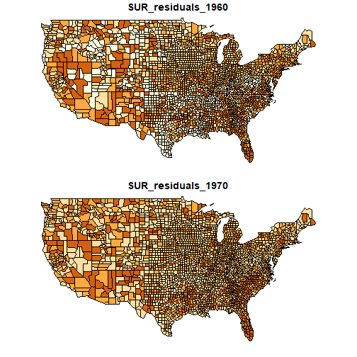

Figure 4: Quantile Map of LS residuals for SUR-SIM model

```r
res <- residuals(sur.sim)
q <- quantile(res[[1]])
NCOVR.sf$SUR_residuals_1960 <- (res[[1]] > q[2]) + (res[[1]] > q[3]) + (res[[1]] >= q[4]) + 1
q <- quantile(res[[2]])
NCOVR.sf$SUR_residuals_1970 <- (res[[2]]>q[1]) + (res[[2]]>q[3]) + (res[[2]] >= q[4]) + 1
plot(NCOVR.sf[c("SUR_residuals_1960","SUR_residuals_1970")],
     pal = c("#FFFEDE","#FFDFA2", "#FFA93F", "#D5610D"))
```

The battery of Lagrange Multipliers that appear below are obtained with the function `lmtestspsur()`. The output is a list of 5 elements each one of the class `htest`. They are the traditional LM misspecification tests (Anselin and Bera 1998) for omitted spatial elements, adapted to a SUR framework by (Mur, López, and Herrera 2010). All the Multipliers are statistically significant, both the raw and robust LMs as well as the joint LM for SARMA processes.

```r
lmtest.sur <- lmtestspsur(formula = formula_sur,
                          listw = lwncovr, data = NCOVR.sf)
print(lmtest.sur)
```

```
#> [[1]]
#>
#>  LM-SUR-SLM
#>
#> data:  NCOVR.sf
#> LM-stat = 408.46, df = 2, p-value < 2.2e-16
#>
#>
#> [[2]]
#>
#>  LM-SUR-SEM
#>
#> data:  NCOVR.sf
#> LM-stat = 382.82, df = 2, p-value < 2.2e-16
#>
#>
#> [[3]]
#>
#>  LM*-SUR-SLM
#>
#> data:  NCOVR.sf
#> LM-stat = 37.779, df = 2, p-value = 6.256e-09
#>
#>
#> [[4]]
#>
#>  LM*-SUR-SEM
#>
#> data:  NCOVR.sf
#> LM-stat = 12.144, df = 2, p-value = 0.002306
#>
#>
#> [[5]]
#>
#>  LM-SUR-SARAR
#>
#> data:  NCOVR.sf
#> LM-stat = 420.6, df = 4, p-value < 2.2e-16
```

The conclusion is that the simple SUR model of expression (3.1) is misspecified due of the omission of relevant spatial elements. The problem for the user is the identification of the elements of spatial structure that are missing from the equation. In fact, all the Multipliers are statistically significant, which would point to a SUR-SARAR specification.

As a way of example, the next Section estimates all the possible spatial configurations of a SUR model by using the function `spsurml()`.

# 4 Estimation of spatial SUR models

As said, **spsur** is an R package whose main objective is to estimate and test SUR models with a given spatial structure. It is assumed that the same spatial structure appears in all time periods and equations. The catalog of spatial specification that this package can process are

- SUR-SLX. SUR model with lags of the X variables.
- SUR-SLM. SUR model with lags of the endogenous variables.
- SUR-SEM. SUR model with spatial errors.
- SUR-SDM. SUR model with lags of the endogenous and of the X variables, or Spatial Durbin.
- SUR-SDEM. SUR model with with lags of the X variables and spatial errors.
- SUR-SARAR. SUR model with lags of the of the endogenous variables and spatial errors.
- SUR-GNM. SUR model with lags of the of the endogenous variables, lags of the X variables and lags spatial errors. This specification nest the rest of models.

The common estimation procedure for the seven cases is maximum-likelihood, ML, whereas the SUR-SLM and SUR-SDM can also be estimated by Three Stage-Least-Squares, 3SLS. Bivand and Piras (2015) offer an excellent revision of estimation methods in spatial econometrics, whereas López, Mı́nguez, and Mur (2020) focus specifically in the comparison of ML against 3SLS. First, we discuss the maximum likelihood approach and finish the Section with a few comments in relation to 3SLS.

## 4.1 SUR-SLX model

The SUR-SLX model includes spatial lags of of the X variables, assumed to be exogenous. The user should specify the argument *type = “slx”* in the function `spsurml()`

```r
sur.slx <- spsurml(formula = formula_sur, listw = lwncovr,
                   type = "slx",data = NCOVR.sf)
```

```
#> Initial point:
#> log_lik:  -18855.23
#> Iteration:  1  log_lik:  -18855.21
#> Iteration:  2  log_lik:  -18855.21
#> Time to fit the model:  0.07  seconds
#> Time to compute covariances:  0.22  seconds
```

```r
summary(sur.slx)
```

```
#> Call:
#> spsurml(formula = formula_sur, data = NCOVR.sf, listw = lwncovr,
#>     type = "slx")
#>
#>
#> Spatial SUR model type:  slx
#>
#> Equation  1
#>                Estimate Std. Error t value  Pr(>|t|)
#> (Intercept)_1  9.401023   0.853874 11.0099 < 2.2e-16 ***
#> RD60_1         1.389561   0.198873  6.9872 3.101e-12 ***
#> PS60_1         0.355592   0.139128  2.5559 0.0106166 *
#> MA60_1        -0.166326   0.029978 -5.5482 3.007e-08 ***
#> DV60_1         0.678313   0.127574  5.3170 1.092e-07 ***
#> UE60_1         0.070046   0.045620  1.5354 0.1247268
#> SOUTH_1       -0.526364   0.854111 -0.6163 0.5377384
#> lag.RD60_1     0.586938   0.258467  2.2708 0.0231911 *
#> lag.PS60_1     0.178879   0.188822  0.9473 0.3435032
#> lag.MA60_1    -0.105026   0.039828 -2.6370 0.0083851 **
#> lag.DV60_1     1.026468   0.185926  5.5208 3.512e-08 ***
#> lag.UE60_1    -0.356145   0.070416 -5.0577 4.366e-07 ***
#> lag.SOUTH_1    3.210360   0.913474  3.5145 0.0004438 ***
#> ---
#> Signif. codes:  0 '***' 0.001 '**' 0.01 '*' 0.05 '.' 0.1 ' ' 1
#> R-squared: 0.3111
#>   Equation  2
#>                Estimate Std. Error t value  Pr(>|t|)
#> (Intercept)_2 12.580067   1.089163 11.5502 < 2.2e-16 ***
#> RD70_2         2.524805   0.221782 11.3842 < 2.2e-16 ***
#> PS70_2         0.645347   0.171796  3.7565 0.0001739 ***
#> MA70_2        -0.086883   0.030887 -2.8129 0.0049246 **
#> DV70_2         1.108540   0.134863  8.2197 2.466e-16 ***
#> UE70_2        -0.079101   0.067060 -1.1796 0.2382249
#> SOUTH_2       -0.472159   1.062209 -0.4445 0.6566924
#> lag.RD70_2     0.208400   0.306689  0.6795 0.4968369
#> lag.PS70_2     0.194587   0.234474  0.8299 0.4066346
#> lag.MA70_2    -0.229987   0.045301 -5.0769 3.950e-07 ***
#> lag.DV70_2     0.275648   0.199942  1.3786 0.1680566
#> lag.UE70_2    -0.332812   0.097684 -3.4070 0.0006610 ***
#> lag.SOUTH_2    4.368685   1.145674  3.8132 0.0001385 ***
#> ---
#> Signif. codes:  0 '***' 0.001 '**' 0.01 '*' 0.05 '.' 0.1 ' ' 1
#> R-squared: 0.3729
#>
#> Variance-Covariance Matrix of inter-equation residuals:
#>  21.990566  6.872353
#>   6.872353 33.903587
#> Correlation Matrix of inter-equation residuals:
#>  1.0000000 0.2516891
#>  0.2516891 1.0000000
#>
#>  R-sq. pooled: 0.363
#>  Breusch-Pagan: 195.4  p-value: (2.08e-44)
```

```r
formulaD <-  ~ DV60 |  MA70 + UE70
sur.slx2 <- spsurml(formula = formula_sur, listw = lwncovr,
                    type = "slx", Durbin = formulaD,
                    data = NCOVR.sf)
```

```
#> Initial point:
#> log_lik:  -18884.89
#> Iteration:  1  log_lik:  -18884.85
#> Iteration:  2  log_lik:  -18884.85
#> Time to fit the model:  0.08  seconds
#> Time to compute covariances:  0.01  seconds
```

```r
summary(sur.slx2)
```

```
#> Call:
#> spsurml(formula = formula_sur, data = NCOVR.sf, listw = lwncovr,
#>     type = "slx", Durbin = formulaD)
#>
#>
#> Spatial SUR model type:  slx
#>
#> Equation  1
#>                Estimate Std. Error  t value  Pr(>|t|)
#> (Intercept)_1  7.450241   0.646059  11.5318 < 2.2e-16 ***
#> RD60_1         1.817856   0.124964  14.5470 < 2.2e-16 ***
#> PS60_1         0.431101   0.094683   4.5531 5.388e-06 ***
#> MA60_1        -0.224789   0.019122 -11.7552 < 2.2e-16 ***
#> DV60_1         0.794215   0.123873   6.4115 1.548e-10 ***
#> UE60_1        -0.081720   0.034482  -2.3699   0.01782 *
#> SOUTH_1        2.720772   0.231840  11.7356 < 2.2e-16 ***
#> lag.DV60_1     0.671427   0.171205   3.9218 8.886e-05 ***
#> ---
#> Signif. codes:  0 '***' 0.001 '**' 0.01 '*' 0.05 '.' 0.1 ' ' 1
#> R-squared: 0.2999
#>   Equation  2
#>                Estimate Std. Error t value  Pr(>|t|)
#> (Intercept)_2 12.537289   1.066144 11.7595 < 2.2e-16 ***
#> RD70_2         2.703698   0.148068 18.2598 < 2.2e-16 ***
#> PS70_2         0.753463   0.115901  6.5009 8.612e-11 ***
#> MA70_2        -0.093525   0.029255 -3.1969  0.001396 **
#> DV70_2         1.195748   0.103137 11.5938 < 2.2e-16 ***
#> UE70_2        -0.099544   0.065857 -1.5115  0.130711
#> SOUTH_2        3.727709   0.283142 13.1655 < 2.2e-16 ***
#> lag.MA70_2    -0.213519   0.041963 -5.0882 3.721e-07 ***
#> lag.UE70_2    -0.248043   0.089825 -2.7614  0.005773 **
#> ---
#> Signif. codes:  0 '***' 0.001 '**' 0.01 '*' 0.05 '.' 0.1 ' ' 1
#> R-squared: 0.3684
#>
#> Variance-Covariance Matrix of inter-equation residuals:
#>  22.346575  7.151706
#>   7.151706 34.145145
#> Correlation Matrix of inter-equation residuals:
#>  1.0000000 0.2589045
#>  0.2589045 1.0000000
#>
#>  R-sq. pooled: 0.3562
#>  Breusch-Pagan: 206.8  p-value: (6.87e-47)
```

## 4.2 SUR-SLM model

The specification of the SLM-SUR model that we want to estimate is standard,

$$\begin{equation}
HR_{60} = \rho_{60}WHR_{60} + \beta_{10}+\beta_{11}RD_{60}+\beta_{12}PS_{60}+\beta_{13}MA_{60}+\beta_{14}DV_{60} +\beta_{15}UE_{60} +\beta_{16}SOUTH+\epsilon_{60} \\
HR_{70} = \rho_{60}WHR_{70} + \beta_{20}+\beta_{21}RD_{70}+\beta_{22}PS_{70}+\beta_{23}MA_{70}+\beta_{24}DV_{70} +\beta_{25}UE_{70} +\beta_{26}SOUTH+\epsilon_{70}\\
Corr(\epsilon_{60},\epsilon_{70}) \neq 0
\tag{4.1}
\end{equation}$$

which can be estimated by maximum likelihood using the argument *type = “slm”* in the function `spsurml()`.

A severe handicap of ML is the evaluation of the Jacobian term, which is highly time consuming. We offer some flexibility to the user with the arguments *method =* and *control=* imported from **spatialreg**, Bivand, Pebesma, and Gómez-Rubio (2013). The argument *method =* is used to select the method to evaluate the Jacobian. The options are *eigen*, *Matrix*, *LU*, *Chebyshev* and *MC*. The default is *eigen* and *Matrix* required the **W** matrix to be symmetric. *control=* adds a list of functionalities to expedite the calculus, which can be consulted in the documentation of **spatialreg**.

```r
control <- list(fdHess = TRUE)
sur.slm <- spsurml(formula = formula_sur, listw = lwncovr,
                   method = "LU", type = "slm", control = control,
                   data = NCOVR.sf)
```

```
#> sparse matrix LU decomposition
#> Initial point:   log_lik:  -18771.55  rhos:  0.335 0.376
#> Iteration:  1   log_lik:  -18761.49  rhos:  0.346 0.393
#> Iteration:  2   log_lik:  -18761.48  rhos:  0.347 0.393
#> Iteration:  3   log_lik:  -18761.48  rhos:  0.347 0.393
#> Time to fit the model:  8.66  seconds
#> Computing numerical covariances...
#> Time to compute covariances:  2.15  seconds
```

```r
summary(sur.slm)
```

```
#> Call:
#> spsurml(formula = formula_sur, data = NCOVR.sf, listw = lwncovr,
#>     type = "slm", method = "LU", control = control)
#>
#>
#> Spatial SUR model type:  slm
#>
#> Equation  1
#>                Estimate Std. Error t value  Pr(>|t|)
#> (Intercept)_1  5.607673   0.611299  9.1734 < 2.2e-16 ***
#> RD60_1         1.334419   0.118843 11.2284 < 2.2e-16 ***
#> PS60_1         0.274531   0.089152  3.0794  0.002084 **
#> MA60_1        -0.166839   0.018620 -8.9602 < 2.2e-16 ***
#> DV60_1         0.879403   0.091237  9.6386 < 2.2e-16 ***
#> UE60_1        -0.030445   0.033560 -0.9072  0.364341
#> SOUTH_1        1.506056   0.225406  6.6815 2.572e-11 ***
#> rho_1          0.346695   0.028107 12.3350 < 2.2e-16 ***
#> ---
#> Signif. codes:  0 '***' 0.001 '**' 0.01 '*' 0.05 '.' 0.1 ' ' 1
#> R-squared: 0.3396
#>   Equation  2
#>                Estimate Std. Error t value  Pr(>|t|)
#> (Intercept)_2  5.157484   0.729818  7.0668 1.761e-12 ***
#> RD70_2         2.201353   0.141953 15.5076 < 2.2e-16 ***
#> PS70_2         0.648528   0.111524  5.8151 6.362e-09 ***
#> MA70_2        -0.121851   0.021629 -5.6337 1.842e-08 ***
#> DV70_2         0.987470   0.099146  9.9598 < 2.2e-16 ***
#> UE70_2        -0.168980   0.047050 -3.5915 0.0003314 ***
#> SOUTH_2        1.616949   0.272648  5.9305 3.184e-09 ***
#> rho_2          0.393272   0.026744 14.7053 < 2.2e-16 ***
#> ---
#> Signif. codes:  0 '***' 0.001 '**' 0.01 '*' 0.05 '.' 0.1 ' ' 1
#> R-squared: 0.4154
#>
#> Variance-Covariance Matrix of inter-equation residuals:
#>  21.096585  5.361957
#>   5.361957 31.640805
#> Correlation Matrix of inter-equation residuals:
#>  1.000000 0.207536
#>  0.207536 1.000000
#>
#>  R-sq. pooled: 0.3996
#>  Breusch-Pagan: 132.9  p-value: (9.63e-31)
```

The `plot()` function allows the user to plot both beta and spatial coefficients for all equations of the spsur model. The argument *viewplot* is used to choose between interactive or non-interactive plots.

[figure not shown]

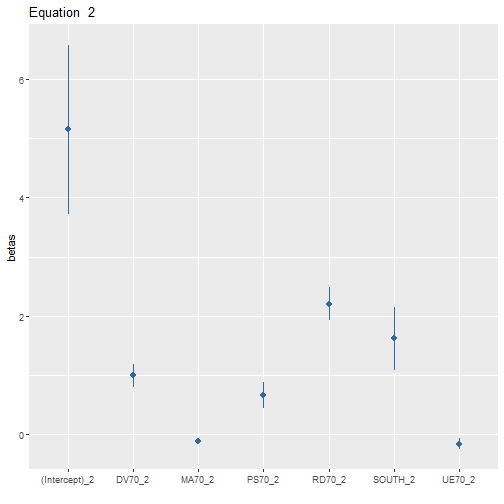

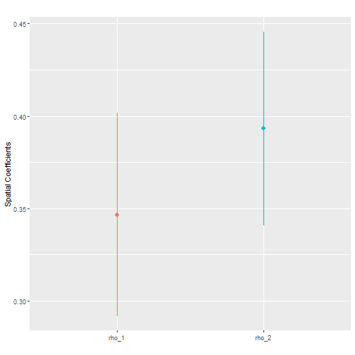

```r
# Interactive plot
plot(sur.slm)
```

The `print()` function is used to print short tables including the values of beta and spatial coefficients as well as p-values of significance test for each coefficient. This can be used as an alternative to `summary()` when a brief output is needed. The *NA* values indicate that the coefficient has not been fitted in the corresponding equation.

```r
print(sur.slm)
```

```
#>             coeff_1 pval_1 coeff_2 pval_2
#> (Intercept)  5.6077  0.000  5.1575      0
#> RD60         1.3344  0.000      NA     NA
#> PS60         0.2745  0.002      NA     NA
#> MA60        -0.1668  0.000      NA     NA
#> DV60         0.8794  0.000      NA     NA
#> UE60        -0.0304  0.364      NA     NA
#> SOUTH        1.5061  0.000  1.6169      0
#> RD70             NA     NA  2.2014      0
#> PS70             NA     NA  0.6485      0
#> MA70             NA     NA -0.1219      0
#> DV70             NA     NA  0.9875      0
#> UE70             NA     NA -0.1690      0
#> rho          0.3467  0.000  0.3933      0
```

## 4.3 SUR-SEM model

The corresponding specification is the following:

$$\begin{equation}
HR_{60} = \beta_{10}+\beta_{11}RD_{60}+\beta_{12}PS_{60}+\beta_{13}MA_{60}+\beta_{14}DV_{60} +\beta_{15}UE_{60} +\beta_{16}SOUTH+u_{60} \ ; \\ u_{60}=\lambda_{60}W u_{60}+\epsilon_{60}\\
\\
HR_{70} = \beta_{20}+\beta_{21}RD_{70}+\beta_{22}PS_{70}+\beta_{23}MA_{70}+\beta_{24}DV_{70} +\beta_{25}UE_{70} +\beta_{26}SOUTH+u_{70} ; \\ u_{70}=\lambda_{70}W u_{70}+\epsilon_{70} \\
\\
Corr(\epsilon_{60},\epsilon_{70}) \neq 0
\tag{4.2}
\end{equation}$$

```r
sur.sem <- spsurml(formula = formula_sur, listw = lwncovr,
                   method = "LU", type = "sem",
                   control = control, data = NCOVR.sf)
```

```
#> sparse matrix LU decomposition
#> Initial point:   log_lik:  -18779.5  lambdas:  0.334 0.409
#> Iteration:  1  log_lik:  -18769.69  lambdas:  0.347 0.43
#> Iteration:  2  log_lik:  -18769.67  lambdas:  0.348 0.43
#> Iteration:  3  log_lik:  -18769.67  lambdas:  0.348 0.43
#> Time to fit the model:  11.62  seconds
#> Computing numerical covariances...
#> Time to compute covariances:  2.82  seconds
```

```r
summary(sur.sem)
```

```
#> Call:
#> spsurml(formula = formula_sur, data = NCOVR.sf, listw = lwncovr,
#>     type = "sem", method = "LU", control = control)
#>
#>
#> Spatial SUR model type:  sem
#>
#> Equation  1
#>                 Estimate Std. Error  t value  Pr(>|t|)
#> (Intercept)_1  7.5049435  0.6128151  12.2467 < 2.2e-16 ***
#> RD60_1         1.6575939  0.1191372  13.9133 < 2.2e-16 ***
#> PS60_1         0.3199694  0.0893774   3.5800 0.0003463 ***
#> MA60_1        -0.2057071  0.0186664 -11.0202 < 2.2e-16 ***
#> DV60_1         0.9407399  0.0914624  10.2855 < 2.2e-16 ***
#> UE60_1         0.0026013  0.0336394   0.0773 0.9383649
#> SOUTH_1        2.6240053  0.2259739  11.6120 < 2.2e-16 ***
#> lambda_1       0.3476493  0.0303349  11.4604 < 2.2e-16 ***
#> ---
#> Signif. codes:  0 '***' 0.001 '**' 0.01 '*' 0.05 '.' 0.1 ' ' 1
#> R-squared: 0.3369
#>   Equation  2
#>                Estimate Std. Error t value  Pr(>|t|)
#> (Intercept)_2  6.735502   0.728709  9.2431 < 2.2e-16 ***
#> RD70_2         2.804145   0.141737 19.7841 < 2.2e-16 ***
#> PS70_2         0.731634   0.111361  6.5699 5.447e-11 ***
#> MA70_2        -0.132338   0.021596 -6.1279 9.459e-10 ***
#> DV70_2         1.111776   0.098994 11.2307 < 2.2e-16 ***
#> UE70_2        -0.146819   0.046974 -3.1255  0.001783 **
#> SOUTH_2        3.458503   0.272244 12.7037 < 2.2e-16 ***
#> lambda_2       0.430480   0.028888 14.9016 < 2.2e-16 ***
#> ---
#> Signif. codes:  0 '***' 0.001 '**' 0.01 '*' 0.05 '.' 0.1 ' ' 1
#> R-squared: 0.4178
#>
#> Variance-Covariance Matrix of inter-equation residuals:
#>  21.20416  5.39982
#>   5.39982 31.54910
#> Correlation Matrix of inter-equation residuals:
#>  1.0000000 0.2087734
#>  0.2087734 1.0000000
#>
#>  R-sq. pooled:   0.4
#>  Breusch-Pagan: 134.5  p-value: (4.33e-31)
```

[figure not shown]

```r
# Non-interactive plot
if (require(gridExtra)) {
  pl <- plot(sur.sem, viewplot = FALSE)
  grid.arrange(pl$lplbetas[[1]], pl$lplbetas[[2]],
               pl$pldeltas, nrow = 3)
}
```

[output not shown]

## 4.4 SUR-SDEM model

The specification of a spatial Durbin model with spatial errors and a SUR framework is the following

$$\begin{equation}
HR_{60} = \beta_{10}+\beta_{11}RD_{60}+\beta_{12}PS_{60}+\beta_{13}MA_{60}+\beta_{14}DV_{60} +\beta_{15}UE_{60} +\beta_{16}SOUTH+u_{60} +\theta_{1}WDV_{60}\ ; \\ u_{60}=\lambda_{60}W u_{60}+\epsilon_{60}\\
\\
HR_{70} = \beta_{20}+\beta_{21}RD_{70}+\beta_{22}PS_{70}+\beta_{23}MA_{70}+\beta_{24}DV_{70} +\beta_{25}UE_{70} +\beta_{26}SOUTH+u_{70}+\theta_{2}WMA_{70}+\theta_{3}WUE_{70} ; \\ u_{70}=\lambda_{70}W u_{70}+\epsilon_{70} \\
\\
Corr(\epsilon_{60},\epsilon_{70}) \neq 0
\tag{4.3}
\end{equation}$$

Note that the specificaction above, in spite of its name, does not include lags of the endogenous variables; only lags of the X variables combined with spatial errors. The model is estimated by ML, with *method = “LU”* and *fdHess = TRUE* in the argument control. To shorten the output, we use the argument *Durbin=* to restrict the spatial lags of the X variables that we want to see in the SUR equations. The results appear below.

```r
formulaD <-  ~ DV60 |  MA70 + UE70
sur.sdem <- spsurml(formula = formula_sur, listw = lwncovr,
                   method = "LU", type = "sdem", Durbin = formulaD,
                   control = control, data = NCOVR.sf)
```

```
#> sparse matrix LU decomposition
#> Initial point:   log_lik:  -18764.09  lambdas:  0.324 0.393
#> Iteration:  1  log_lik:  -18755.77  lambdas:  0.337 0.411
#> Iteration:  2  log_lik:  -18755.76  lambdas:  0.338 0.411
#> Iteration:  3  log_lik:  -18755.76  lambdas:  0.338 0.411
#> Time to fit the model:  12.02  seconds
#> Computing numerical covariances...
#> Time to compute covariances:  2.8  seconds
```

```r
summary(sur.sdem)
```

```
#> Call:
#> spsurml(formula = formula_sur, data = NCOVR.sf, listw = lwncovr,
#>     type = "sdem", Durbin = formulaD, method = "LU", control = control)
#>
#>
#> Spatial SUR model type:  sdem
#>
#> Equation  1
#>                Estimate Std. Error  t value  Pr(>|t|)
#> (Intercept)_1  6.758640   0.630562  10.7184 < 2.2e-16 ***
#> RD60_1         1.773521   0.122008  14.5362 < 2.2e-16 ***
#> PS60_1         0.415781   0.092226   4.5083 6.656e-06 ***
#> MA60_1        -0.207591   0.018652 -11.1298 < 2.2e-16 ***
#> DV60_1         0.763530   0.121488   6.2848 3.508e-10 ***
#> UE60_1        -0.014819   0.033820  -0.4382 0.6612829
#> SOUTH_1        2.627198   0.225838  11.6331 < 2.2e-16 ***
#> lag.DV60_1     0.648362   0.168515   3.8475 0.0001205 ***
#> lambda_1       0.337788   0.030430  11.1004 < 2.2e-16 ***
#> ---
#> Signif. codes:  0 '***' 0.001 '**' 0.01 '*' 0.05 '.' 0.1 ' ' 1
#> R-squared: 0.3382
#>   Equation  2
#>                Estimate Std. Error t value  Pr(>|t|)
#> (Intercept)_2 12.121123   1.029051 11.7789 < 2.2e-16 ***
#> RD70_2         2.747320   0.142525 19.2761 < 2.2e-16 ***
#> PS70_2         0.710438   0.111236  6.3868 1.818e-10 ***
#> MA70_2        -0.095328   0.028288 -3.3699 0.0007566 ***
#> DV70_2         1.127622   0.099328 11.3525 < 2.2e-16 ***
#> UE70_2        -0.094322   0.063879 -1.4766 0.1398408
#> SOUTH_2        3.392350   0.272004 12.4717 < 2.2e-16 ***
#> lag.MA70_2    -0.192663   0.040742 -4.7289 2.308e-06 ***
#> lag.UE70_2    -0.217846   0.087162 -2.4993 0.0124689 *
#> lambda_2       0.411429   0.029221 14.0797 < 2.2e-16 ***
#> ---
#> Signif. codes:  0 '***' 0.001 '**' 0.01 '*' 0.05 '.' 0.1 ' ' 1
#> R-squared:  0.42
#>
#> Variance-Covariance Matrix of inter-equation residuals:
#>  21.154911  5.381894
#>   5.381894 31.421125
#> Correlation Matrix of inter-equation residuals:
#>  1.0000000 0.2087462
#>  0.2087462 1.0000000
#>
#>  R-sq. pooled: 0.4018
#>  Breusch-Pagan: 134.4  p-value: (4.4e-31)
```

[figure not shown]

```r
# Non-interactive plot
if (require(gridExtra)) {
  pl <- plot(sur.sdem, viewplot = FALSE)
  grid.arrange(pl$lplbetas[[1]], pl$lplbetas[[2]],
               pl$pldeltas, nrow = 3)
}
```

[output not shown]

## 4.5 SUR-SDM model

To estimate a full spatial Durbin model set the argument type to *type = “sdm”*. Moreover, the same as in other previous cases, we can restrict the list of lags of the X variables that we want to appear in the equations, by using the argument *Durbin =*.

```r
formulaD <-  ~ RD60 + PS60 + MA60 + DV60 |  RD70 + PS70 + DV70
sur.sdm <- spsurml(formula = formula_sur, listw = lwncovr,
                   type = "sdm", method = "LU",
                   Durbin = formulaD, data = NCOVR.sf)
```

```
#> sparse matrix LU decomposition
#> Initial point:   log_lik:  -18758.26  rhos:  0.325 0.411
#> Iteration:  1   log_lik:  -18747.79  rhos:  0.338 0.431
#> Iteration:  2   log_lik:  -18747.77  rhos:  0.339 0.431
#> Iteration:  3   log_lik:  -18747.77  rhos:  0.339 0.431
#> Time to fit the model:  9.85  seconds
#> Time to compute covariances:  21.21  seconds
```

```r
summary(sur.sdm)
```

```
#> Call:
#> spsurml(formula = formula_sur, data = NCOVR.sf, listw = lwncovr,
#>     type = "sdm", Durbin = formulaD, method = "LU")
#>
#>
#> Spatial SUR model type:  sdm
#>
#> Equation  1
#>                Estimate Std. Error t value  Pr(>|t|)
#> (Intercept)_1  5.199036   0.823754  6.3114 2.958e-10 ***
#> RD60_1         1.530960   0.193838  7.8982 3.329e-15 ***
#> PS60_1         0.404736   0.135836  2.9796  0.002898 **
#> MA60_1        -0.175412   0.029214 -6.0044 2.030e-09 ***
#> DV60_1         0.699457   0.125303  5.5821 2.478e-08 ***
#> UE60_1        -0.037883   0.033872 -1.1184  0.263422
#> SOUTH_1        1.625112   0.263591  6.1653 7.483e-10 ***
#> lag.RD60_1    -0.208383   0.254629 -0.8184  0.413171
#> lag.PS60_1    -0.134430   0.181435 -0.7409  0.458767
#> lag.MA60_1     0.012782   0.038836  0.3291  0.742061
#> lag.DV60_1     0.342637   0.183159  1.8707  0.061433 .
#> rho_1          0.338837   0.032761 10.3427 < 2.2e-16 ***
#> ---
#> Signif. codes:  0 '***' 0.001 '**' 0.01 '*' 0.05 '.' 0.1 ' ' 1
#> R-squared: 0.3404
#>   Equation  2
#>                Estimate Std. Error t value  Pr(>|t|)
#> (Intercept)_2  5.529591   0.779831  7.0908 1.483e-12 ***
#> RD70_2         2.686495   0.210748 12.7474 < 2.2e-16 ***
#> PS70_2         0.569334   0.161980  3.5148 0.0004432 ***
#> MA70_2        -0.128224   0.021944 -5.8433 5.380e-09 ***
#> DV70_2         1.158369   0.128896  8.9869 < 2.2e-16 ***
#> UE70_2        -0.143309   0.047553 -3.0137 0.0025915 **
#> SOUTH_2        2.072420   0.330277  6.2748 3.740e-10 ***
#> lag.RD70_2    -1.088314   0.291587 -3.7324 0.0001914 ***
#> lag.PS70_2    -0.016707   0.217749 -0.0767 0.9388449
#> lag.DV70_2    -0.485267   0.185833 -2.6113 0.0090415 **
#> rho_2          0.431471   0.029678 14.5384 < 2.2e-16 ***
#> ---
#> Signif. codes:  0 '***' 0.001 '**' 0.01 '*' 0.05 '.' 0.1 ' ' 1
#> R-squared: 0.4219
#>
#> Variance-Covariance Matrix of inter-equation residuals:
#>  21.071758  5.326328
#>   5.326328 31.298884
#> Correlation Matrix of inter-equation residuals:
#>  1.0000000 0.2074021
#>  0.2074021 1.0000000
#>
#>  R-sq. pooled: 0.4039
#>  Breusch-Pagan: 132.7  p-value: (1.05e-30)
#>  LMM: 124.48  p-value: (6.63e-29)
```

[figure not shown]

```r
# Non-interactive plot
if (require(gridExtra)) {
  pl <- plot(sur.sdm, viewplot = FALSE)
  grid.arrange(pl$lplbetas[[1]], pl$lplbetas[[2]],
               pl$pldeltas, nrow = 3)
}
```

[output not shown]

## 4.6 SUR-SARAR model

The key argument to build a SARAR model from a single SUR specification, like that in of (3.1), is *type = “sarar”*.

```r
sur.sarar <- spsurml(formula = formula_sur, listw = lwncovr,
                     type = "sarar", method = "LU",
                     control= control,
                     data = NCOVR.sf)
```

```
#> sparse matrix LU decomposition
#> Initial point:   log_lik:  -18751.87  rhos:  0.648 0.362  lambdas:  -0.623 0.041
#> Iteration:  1  log_lik:  -18724.82  rhos:  0.731 0.46  lambdas:  -0.833 -0.091
#> Iteration:  2  log_lik:  -18722.65  rhos:  0.752 0.478  lambdas:  -0.896 -0.121
#> Iteration:  3  log_lik:  -18722.44  rhos:  0.758 0.483  lambdas:  -0.915 -0.129
#> Iteration:  4  log_lik:  -18722.42  rhos:  0.76 0.485  lambdas:  -0.92 -0.131
#> Iteration:  5  log_lik:  -18722.42  rhos:  0.76 0.485  lambdas:  -0.922 -0.132
#> Iteration:  6  log_lik:  -18722.42  rhos:  0.761 0.485  lambdas:  -0.922 -0.132
#> Time to fit the model:  247.33  seconds
#> Computing numerical covariances...
#> Time to compute covariances:  16.03  seconds
```

```r
summary(sur.sarar)
```

```
#> Call:
#> spsurml(formula = formula_sur, data = NCOVR.sf, listw = lwncovr,
#>     type = "sarar", method = "LU", control = control)
#>
#>
#> Spatial SUR model type:  sarar
#>
#> Equation  1
#>                Estimate Std. Error  t value  Pr(>|t|)
#> (Intercept)_1  2.479266   0.566256   4.3783 1.216e-05 ***
#> RD60_1         0.680964   0.110086   6.1858 6.578e-10 ***
#> PS60_1         0.154374   0.082587   1.8692   0.06164 .
#> MA60_1        -0.080503   0.017248  -4.6673 3.116e-06 ***
#> DV60_1         0.520855   0.084514   6.1630 7.591e-10 ***
#> UE60_1        -0.035781   0.031084  -1.1511   0.24973
#> SOUTH_1        0.325702   0.208805   1.5598   0.11885
#> rho_1          0.760536   0.021699  35.0500 < 2.2e-16 ***
#> lambda_1      -0.922128   0.066464 -13.8742 < 2.2e-16 ***
#> ---
#> Signif. codes:  0 '***' 0.001 '**' 0.01 '*' 0.05 '.' 0.1 ' ' 1
#> R-squared: 0.4405
#>   Equation  2
#>                Estimate Std. Error t value  Pr(>|t|)
#> (Intercept)_2  4.530158   0.725704  6.2424 4.596e-10 ***
#> RD70_2         1.975305   0.141153 13.9941 < 2.2e-16 ***
#> PS70_2         0.603130   0.110901  5.4384 5.582e-08 ***
#> MA70_2        -0.109621   0.021507 -5.0970 3.554e-07 ***
#> DV70_2         0.924493   0.098586  9.3775 < 2.2e-16 ***
#> UE70_2        -0.169193   0.046781 -3.6167 0.0003008 ***
#> SOUTH_2        1.240679   0.271121  4.5761 4.830e-06 ***
#> rho_2          0.485140   0.068908  7.0404 2.126e-12 ***
#> lambda_2      -0.132170   0.122005 -1.0833 0.2787105
#> ---
#> Signif. codes:  0 '***' 0.001 '**' 0.01 '*' 0.05 '.' 0.1 ' ' 1
#> R-squared: 0.4221
#>
#> Variance-Covariance Matrix of inter-equation residuals:
#>  18.104351  4.966429
#>   4.966429 31.289101
#> Correlation Matrix of inter-equation residuals:
#>  1.0000000 0.2086682
#>  0.2086682 1.0000000
#>
#>  R-sq. pooled: 0.4395
#>  Breusch-Pagan: 134.3  p-value: (4.63e-31)
```

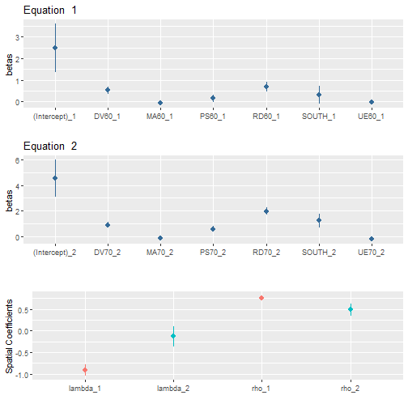

```r
# Non-interactive plot
if (require(gridExtra)) {
  pl <- plot(sur.sarar, viewplot = FALSE)
  grid.arrange(pl$lplbetas[[1]], pl$lplbetas[[2]],
               pl$pldeltas, nrow = 3)
}
```

## 4.7 SUR-GNM model

This is the most general specification of a spatial SUR model. It needs to be chosen as *type = “gnm”*.

```r
sur.gnm <- spsurml(formula = formula_sur, listw = lwncovr,
                     type = "gnm", method = "LU",
                     control= control,
                     data = NCOVR.sf)
```

```
#> sparse matrix LU decomposition
#> Initial point:   log_lik:  -18720.21  rhos:  -0.69 0.542  lambdas:  0.685 -0.239
#> Iteration:  1  log_lik:  -18687.14  rhos:  -0.917 0.645  lambdas:  0.773 -0.426
#> Iteration:  2  log_lik:  -18683.28  rhos:  -0.992 0.669  lambdas:  0.797 -0.476
#> Iteration:  3  log_lik:  -18682.89  rhos:  -1 0.675  lambdas:  0.802 -0.49
#> Iteration:  4  log_lik:  -18682.88  rhos:  -1 0.677  lambdas:  0.802 -0.494
#> Iteration:  5  log_lik:  -18682.88  rhos:  -1 0.678  lambdas:  0.802 -0.495
#> Time to fit the model:  194.16  seconds
#> Computing numerical covariances...
#> Time to compute covariances:  16.59  seconds
```

```r
summary(sur.gnm)
```

```
#> Call:
#> spsurml(formula = formula_sur, data = NCOVR.sf, listw = lwncovr,
#>     type = "gnm", method = "LU", control = control)
#>
#>
#> Spatial SUR model type:  gnm
#>
#> Equation  1
#>                Estimate Std. Error  t value  Pr(>|t|)
#> (Intercept)_1 17.637671   0.762287  23.1378 < 2.2e-16 ***
#> RD60_1         1.558080   0.178061   8.7503 < 2.2e-16 ***
#> PS60_1         0.376947   0.124103   3.0374  0.002397 **
#> MA60_1        -0.180938   0.026815  -6.7476 1.641e-11 ***
#> DV60_1         0.746906   0.114355   6.5315 7.035e-11 ***
#> UE60_1         0.046907   0.041110   1.1410  0.253915
#> SOUTH_1        0.523163   0.760957   0.6875  0.491790
#> lag.RD60_1     2.403661   0.231207  10.3961 < 2.2e-16 ***
#> lag.PS60_1     0.154981   0.168389   0.9204  0.357415
#> lag.MA60_1    -0.323422   0.035598  -9.0855 < 2.2e-16 ***
#> lag.DV60_1     2.115808   0.166330  12.7206 < 2.2e-16 ***
#> lag.UE60_1    -0.286290   0.063278  -4.5243 6.173e-06 ***
#> lag.SOUTH_1    3.652172   0.813929   4.4871 7.352e-06 ***
#> rho_1         -1.000000   0.064391 -15.5300 < 2.2e-16 ***
#> lambda_1       0.801956   0.020253  39.5978 < 2.2e-16 ***
#> ---
#> Signif. codes:  0 '***' 0.001 '**' 0.01 '*' 0.05 '.' 0.1 ' ' 1
#> R-squared: 0.4652
#>   Equation  2
#>                Estimate Std. Error t value  Pr(>|t|)
#> (Intercept)_2  4.388868   1.013975  4.3284 1.526e-05 ***
#> RD70_2         2.570551   0.207109 12.4116 < 2.2e-16 ***
#> PS70_2         0.651371   0.159736  4.0778 4.604e-05 ***
#> MA70_2        -0.077525   0.028820 -2.6900 0.0071643 **
#> DV70_2         1.064836   0.126071  8.4463 < 2.2e-16 ***
#> UE70_2        -0.048163   0.063024 -0.7642 0.4447766
#> SOUTH_2        0.014559   0.986988  0.0148 0.9882313
#> lag.RD70_2    -1.722619   0.286084 -6.0214 1.829e-09 ***
#> lag.PS70_2    -0.387912   0.217997 -1.7794 0.0752177 .
#> lag.MA70_2    -0.033303   0.042225 -0.7887 0.4303147
#> lag.DV70_2    -0.629841   0.186557 -3.3761 0.0007397 ***
#> lag.UE70_2    -0.096449   0.091567 -1.0533 0.2922402
#> lag.SOUTH_2    1.233415   1.064744  1.1584 0.2467401
#> rho_2          0.677561   0.035178 19.2607 < 2.2e-16 ***
#> lambda_2      -0.494567   0.083217 -5.9431 2.951e-09 ***
#> ---
#> Signif. codes:  0 '***' 0.001 '**' 0.01 '*' 0.05 '.' 0.1 ' ' 1
#> R-squared: 0.4614
#>
#> Variance-Covariance Matrix of inter-equation residuals:
#>  17.454940  4.444949
#>   4.444949 29.269587
#> Correlation Matrix of inter-equation residuals:
#>  1.0000000 0.1966524
#>  0.1966524 1.0000000
#>
#>  R-sq. pooled: 0.4725
#>  Breusch-Pagan: 119.3  p-value: (8.99e-28)
```

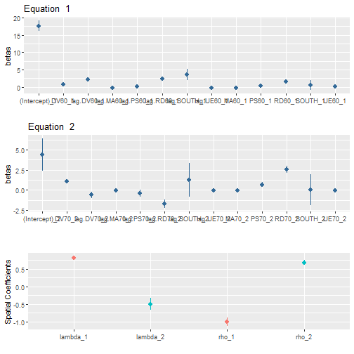

```r
# Non-interactive plot
if (require(gridExtra)) {
  pl <- plot(sur.gnm, viewplot = FALSE)
  grid.arrange(pl$lplbetas[[1]], pl$lplbetas[[2]],
               pl$pldeltas, nrow = 3)
}
```

## 4.8 3SLS estimation of SUR-SLM and SUR-SDM models

We finish this Section by discussing briefly how to estimate a SUR-SLM model using a 3SLS approach (the same applies for the case of a SUR-SDM). The advantage of 3SLS over ML is time computing, because the first consists of a quasi-linear algorithm whereas the second may be highly non-linear and time consuming.

First is the obtaining of the spatial instruments using the information in the X variables, assumed to be exogenous. The matrix of instruments is $H=[X,WX,W^2X,W^3X,...,W^rX]$, with r=2 for the SUR-SLM case and r=3 in case of a SUR-SDM model. This defaults can be changed by using the argument *“maxlagW=”* to the desired integer.

```r
sur.slm.3sls <- spsur3sls(formula = formula_sur,
                          listw = lwncovr,
                          type = "slm", maxlagW = 3,
                          data = NCOVR.sf)
```

```
#> Time to fit the model:  0.27  seconds
```

```r
summary(sur.slm.3sls)
```

```
#> Call:
#> spsur3sls(formula = formula_sur, data = NCOVR.sf, listw = lwncovr,
#>     type = "slm", maxlagW = 3)
#>
#>
#> Spatial SUR model type:  slm
#>
#> Equation  1
#>                 Estimate Std. Error t value  Pr(>|t|)
#> (Intercept)_1  3.6991431  0.8086769  4.5743 4.872e-06 ***
#> RD60_1         1.0126646  0.1479221  6.8459 8.335e-12 ***
#> PS60_1         0.2207921  0.0920915  2.3975   0.01654 *
#> MA60_1        -0.1192853  0.0227998 -5.2319 1.734e-07 ***
#> DV60_1         0.6794240  0.1069872  6.3505 2.299e-10 ***
#> UE60_1        -0.0025294  0.0348838 -0.0725   0.94220
#> SOUTH_1        0.6305568  0.3411165  1.8485   0.06458 .
#> rho_1          0.6055468  0.0723971  8.3642 < 2.2e-16 ***
#> ---
#> Signif. codes:  0 '***' 0.001 '**' 0.01 '*' 0.05 '.' 0.1 ' ' 1
#> R-squared: 0.344
#>   Equation  2
#>                Estimate Std. Error t value  Pr(>|t|)
#> (Intercept)_2  4.611480   0.926852  4.9754 6.688e-07 ***
#> RD70_2         2.078946   0.178233 11.6642 < 2.2e-16 ***
#> PS70_2         0.621482   0.117762  5.2774 1.355e-07 ***
#> MA70_2        -0.110960   0.024743 -4.4846 7.438e-06 ***
#> DV70_2         0.934966   0.108098  8.6493 < 2.2e-16 ***
#> UE70_2        -0.146392   0.049925 -2.9322  0.003378 **
#> SOUTH_2        1.356495   0.436969  3.1043  0.001916 **
#> rho_2          0.450279   0.063105  7.1353 1.076e-12 ***
#> ---
#> Signif. codes:  0 '***' 0.001 '**' 0.01 '*' 0.05 '.' 0.1 ' ' 1
#> R-squared: 0.4186
#>
#> Variance-Covariance Matrix of inter-equation residuals:
#>  21.99787  6.87556
#>   6.87556 33.99110
#> Correlation Matrix of inter-equation residuals:
#>  1.0000000 0.1933044
#>  0.1933044 1.0000000
#>
#>  R-sq. pooled: 0.4029
#>  Breusch-Pagan:   195  p-value: (2.52e-44)
```

As usual, we can activate the argument *“Durbin =”* to restrict the lags of the X variables in the equations of the SUR-SDM model.

```r
formulaD <-  ~ RD60 |PS70 + DV70
sur.sdm.3sls <- spsur3sls(formula = formula_sur,
                          listw = lwncovr, type = "sdm",
                          Durbin = formulaD, data = NCOVR.sf)
```

```
#> Time to fit the model:  0.35  seconds
```

```r
summary(sur.sdm.3sls)
```

```
#> Call:
#> spsur3sls(formula = formula_sur, data = NCOVR.sf, listw = lwncovr,
#>     type = "sdm", Durbin = formulaD)
#>
#>
#> Spatial SUR model type:  sdm
#>
#> Equation  1
#>                 Estimate Std. Error t value  Pr(>|t|)
#> (Intercept)_1  3.4624694  0.8270454  4.1866 2.872e-05 ***
#> RD60_1         1.2449345  0.1901092  6.5485 6.282e-11 ***
#> PS60_1         0.2397027  0.0923574  2.5954  0.009471 **
#> MA60_1        -0.1161461  0.0229283 -5.0656 4.189e-07 ***
#> DV60_1         0.6324323  0.1100932  5.7445 9.660e-09 ***
#> UE60_1        -0.0012328  0.0348684 -0.0354  0.971796
#> SOUTH_1        0.6419150  0.3405172  1.8851  0.059461 .
#> lag.RD60_1    -0.4485605  0.2513252 -1.7848  0.074346 .
#> rho_1          0.6553687  0.0791900  8.2759 < 2.2e-16 ***
#> ---
#> Signif. codes:  0 '***' 0.001 '**' 0.01 '*' 0.05 '.' 0.1 ' ' 1
#> R-squared: 0.3443
#>   Equation  2
#>                Estimate Std. Error t value  Pr(>|t|)
#> (Intercept)_2  4.835165   0.934961  5.1715 2.395e-07 ***
#> RD70_2         1.917663   0.193597  9.9054 < 2.2e-16 ***
#> PS70_2         0.420037   0.164394  2.5551  0.010641 *
#> MA70_2        -0.105585   0.025258 -4.1803 2.951e-05 ***
#> DV70_2         1.167850   0.132806  8.7936 < 2.2e-16 ***
#> UE70_2        -0.119046   0.051768 -2.2996  0.021504 *
#> SOUTH_2        1.116616   0.446322  2.5018  0.012382 *
#> lag.PS70_2     0.215349   0.214306  1.0049  0.314999
#> lag.DV70_2    -0.551847   0.201028 -2.7451  0.006066 **
#> rho_2          0.507463   0.068120  7.4495 1.066e-13 ***
#> ---
#> Signif. codes:  0 '***' 0.001 '**' 0.01 '*' 0.05 '.' 0.1 ' ' 1
#> R-squared: 0.4222
#>
#> Variance-Covariance Matrix of inter-equation residuals:
#>  21.933463  6.773914
#>   6.773914 33.894781
#> Correlation Matrix of inter-equation residuals:
#>  1.0000000 0.1870956
#>  0.1870956 1.0000000
#>
#>  R-sq. pooled: 0.4053
#>  Breusch-Pagan: 190.4  p-value: (2.58e-43)
```

In the example above we have used the default in the argument *“maxlagW=”*, 3 for a SUR-SDM.

# 5 Testing for the specification

**spsur** includes a collection of test which may help the user to improve the specification. Some of them appear routinely as part of the output of the estimation of spatial SUR models whereas others require the intervention of the user. Below we discuss what we consider the most interest tests for the user.

## 5.1 Routine tests

**spsur** deals with SUR models applied in a spatial setting and, thus, is important to control for the SUR nature of the system of equations and for the symptoms of spatial misspecification. In the first case we are refering to the well known Breusch-Pagan LM test (Breusch and Pagan (1980)) of diagonality of the covariance matrix of the SUR residuals. This test appears in the last line of the table of results for any estimated SUR model. Furthermore, The value of the statistic can be recovered using the command `print()`.

```r
print(sur.sim$BP)
```

```
#> [1] 211.1929
```

```r
print(sur.slm$BP)
```

```
#> [1] 132.8747
```

```r
print(sur.slm.3sls$BP)
```

```
#> [1] 195.0408
```

The second issue is solved by using the Marginal Lagrange Multipliers, $LM(\lambda|\rho)$ and $LM(\rho|\lambda)$ (see López, Mur, and Angulo (2014)), which tests for omitted spatial structure, conditional to the estimated spatial SUR model . That is, the SUR-SLM and SUR-SDM models include spatial lags of the endogenous variables in the right hand side of the equations, but we may wonder if we need also of spatial errors. This is the purpose of the $LM(\lambda|\rho)$ Multiplier. Moreover, in the SUR-SEM and SUR-SDEM models, we may wonder if spatial errors are enough or we would need the introduction of lags of the endogeneous variables, which is the purpose of the $LM(\rho|\lambda)$ Multiplier.

The value of this test appears at the bottom of the table of estimation results for any of the four SUR models, indicated under the heading of *LMM* (the Marginal Multipliers makes no sense for the SUR-SLX and SUR-SARAR cases). This test can be viewed as a general measure of misspecification in what respects the spatial structure of the model. Finaly, note that the Marginal Multipliers are obtained, for reasons of calculus, only for the ML algorithm and under the option *fdHess = FALSE* which is the default (you may change it to *fdHess = TRUE*, using the argument *control=*); in fact, we need the analytical Hessian.

```r
control <- list(fdHess = FALSE)
sur.slm1 <- spsurml(formula = formula_sur, listw = lwncovr,
                   method = "LU", type = "slm",
                   data = NCOVR.sf)
```

```
#> sparse matrix LU decomposition
#> Initial point:   log_lik:  -18771.55  rhos:  0.335 0.376
#> Iteration:  1   log_lik:  -18761.49  rhos:  0.346 0.393
#> Iteration:  2   log_lik:  -18761.48  rhos:  0.347 0.393
#> Iteration:  3   log_lik:  -18761.48  rhos:  0.347 0.393
#> Time to fit the model:  8.59  seconds
#> Time to compute covariances:  15.02  seconds
```

```r
summary(sur.slm1)
```

```
#> Call:
#> spsurml(formula = formula_sur, data = NCOVR.sf, listw = lwncovr,
#>     type = "slm", method = "LU")
#>
#>
#> Spatial SUR model type:  slm
#>
#> Equation  1
#>                Estimate Std. Error t value  Pr(>|t|)
#> (Intercept)_1  5.607673   0.645042  8.6935 < 2.2e-16 ***
#> RD60_1         1.334419   0.124778 10.6943 < 2.2e-16 ***
#> PS60_1         0.274531   0.089300  3.0742   0.00212 **
#> MA60_1        -0.166839   0.019299 -8.6449 < 2.2e-16 ***
#> DV60_1         0.879403   0.093120  9.4437 < 2.2e-16 ***
#> UE60_1        -0.030445   0.033560 -0.9072   0.36435
#> SOUTH_1        1.506056   0.245815  6.1268 9.522e-10 ***
#> rho_1          0.346695   0.030621 11.3223 < 2.2e-16 ***
#> ---
#> Signif. codes:  0 '***' 0.001 '**' 0.01 '*' 0.05 '.' 0.1 ' ' 1
#> R-squared: 0.3396
#>   Equation  2
#>                Estimate Std. Error t value  Pr(>|t|)
#> (Intercept)_2  5.157484   0.753684  6.8430 8.504e-12 ***
#> RD70_2         2.201353   0.151750 14.5064 < 2.2e-16 ***
#> PS70_2         0.648528   0.112107  5.7849 7.612e-09 ***
#> MA70_2        -0.121851   0.021874 -5.5705 2.648e-08 ***
#> DV70_2         0.987470   0.100386  9.8367 < 2.2e-16 ***
#> UE70_2        -0.168980   0.047095 -3.5880 0.0003358 ***
#> SOUTH_2        1.616949   0.304425  5.3115 1.126e-07 ***
#> rho_2          0.393272   0.028399 13.8482 < 2.2e-16 ***
#> ---
#> Signif. codes:  0 '***' 0.001 '**' 0.01 '*' 0.05 '.' 0.1 ' ' 1
#> R-squared: 0.4154
#>
#> Variance-Covariance Matrix of inter-equation residuals:
#>  21.096585  5.361957
#>   5.361957 31.640805
#> Correlation Matrix of inter-equation residuals:
#>  1.000000 0.207536
#>  0.207536 1.000000
#>
#>  R-sq. pooled: 0.3996
#>  Breusch-Pagan: 132.9  p-value: (9.63e-31)
#>  LMM: 27.477  p-value: (1.59e-07)
```

## 5.2 Linear restrictions on the $\beta$ parameters

**spsur** allows to tests linear restrictions on the $\beta$ parameters of a SUR model that has been previously estimated. The restrictions may refer to parameters of the same or of different equations and are solved through a Wald test, asymptotically distributed as a $\chi^2$ with degrees of freedom equal to the number of restrictions involved in the test. In this sense, the function `wald_betas()` offers a great flexibility; it requires the especification of three arguments:

1. The matrix of restrictions: A $(r \times K)$ matrix, being r the number of restrictions a K the total number of $\beta$ parameters in the models; R1 in the example below.
2. The value of the restrictions under the null hypothesis. This is a a $(r \times 1)$ vector; b1 in the example below.
3. The model where we wish to evaluate these restrictions

For example, suppose that we want to test if the parameters associated with variable SOUTH in the two equations of the model (4.1) are equal; so that
$$\begin{equation}
H_0:\beta_{16} = \beta_{26} \\ H_A:\beta_{16} \neq \beta_{26}
\tag{5.1}
\end{equation}$$

```r
R1 <- matrix(c(0, 0, 0, 0, 0, 0, 1,
               0, 0, 0, 0, 0, 0, -1), nrow = 1)
b1 <- matrix(0, ncol = 1)
waldbeta1 <- wald_betas(sur.slm, R1, b1)
print(waldbeta1)
```

```
#>
#>  Wald test on beta parameters
#>
#> data:  NCOVR.sf
#> Wald test = 0.12143, df = 1, p-value = 0.7275
```

The test confirms our suspicious that both coefficients are not statistically different. Therefore, the user would be surely interested in the restricted version where the two coefficients are indeed the same. That is

$$\begin{equation}
HR_{60} = \beta_{10}+\beta_{11}RD_{60}+\beta_{12}PS_{60}+\beta_{13}MA_{60}+\beta_{14}DV_{60} +\beta_{15}UE_{60} +\beta_{16}SOUTH+\epsilon_{60}\\
HR_{70} = \beta_{20}+\beta_{21}RD_{70}+\beta_{22}PS_{70}+\beta_{23}MA_{70}+\beta_{24}DV_{70} +\beta_{25}UE_{70} +\beta_{16}SOUTH+\epsilon_{70} \\
Corr(\epsilon_{60},\epsilon_{70}) \neq 0
\tag{5.2}
\end{equation}$$

**spsur** allows easily for the estimation of a linearly restricted model, in the $\beta$ coefficients, just by adding two new arguments *“R=”* and *“b=* to the respective `spsurml()`function. For example, in the case of the SUR-SLM model analyzed so far, we obtain

```r
R1 <- matrix(c(0,0,0,0,0,0,1,
               0,0,0,0,0,0,-1), nrow=1)
b1 <- matrix(0, ncol = 1)
sur.slm.r <- spsurml(formula = formula_sur, listw = lwncovr,
                     type = "slm", R = R1, b = b1,
                     control = control, data = NCOVR.sf)
```

```
#> neighbourhood matrix eigenvalues
#> Computing eigenvalues ...
#>
#> Initial point:   log_lik:  -18771.73  rhos:  0.332 0.381
#> Iteration:  1   log_lik:  -18761.54  rhos:  0.344 0.396
#> Iteration:  2   log_lik:  -18761.53  rhos:  0.345 0.396
#> Iteration:  3   log_lik:  -18761.53  rhos:  0.345 0.396
#> Time to fit the model:  3.28  seconds
#> Time to compute covariances:  13.44  seconds
```

```r
summary(sur.slm.r)
```

```
#> Call:
#> spsurml(formula = formula_sur, data = NCOVR.sf, listw = lwncovr,
#>     type = "slm", R = R1, b = b1, control = control)
#>
#>
#> Spatial SUR model type:  slm
#>
#> Equation  1
#>                Estimate Std. Error t value  Pr(>|t|)
#> (Intercept)_1  5.591069   0.643010  8.6951 < 2.2e-16 ***
#> RD60_1         1.325351   0.121683 10.8918 < 2.2e-16 ***
#> PS60_1         0.271923   0.088913  3.0583  0.002236 **
#> MA60_1        -0.166639   0.019291 -8.6382 < 2.2e-16 ***
#> DV60_1         0.879342   0.093132  9.4419 < 2.2e-16 ***
#> UE60_1        -0.030164   0.033527 -0.8997  0.368308
#> SOUTH_1        1.546569   0.206496  7.4896 7.882e-14 ***
#> rho_1          0.344663   0.029622 11.6352 < 2.2e-16 ***
#> ---
#> Signif. codes:  0 '***' 0.001 '**' 0.01 '*' 0.05 '.' 0.1 ' ' 1
#> R-squared: 0.3394
#>   Equation  2
#>                Estimate Std. Error t value  Pr(>|t|)
#> (Intercept)_2  5.167209   0.752040  6.8709 7.007e-12 ***
#> RD70_2         2.215108   0.146012 15.1707 < 2.2e-16 ***
#> PS70_2         0.652578   0.111367  5.8597 4.877e-09 ***
#> MA70_2        -0.121543   0.021865 -5.5588 2.831e-08 ***
#> DV70_2         0.988142   0.100342  9.8477 < 2.2e-16 ***
#> UE70_2        -0.170805   0.046532 -3.6707 0.0002439 ***
#> SOUTH_2        1.546569   0.206496  7.4896 7.882e-14 ***
#> rho_2          0.396384   0.026442 14.9909 < 2.2e-16 ***
#> ---
#> Signif. codes:  0 '***' 0.001 '**' 0.01 '*' 0.05 '.' 0.1 ' ' 1
#> R-squared: 0.4157
#>
#> Variance-Covariance Matrix of inter-equation residuals:
#>  21.101489  5.357079
#>   5.357079 31.628040
#> Correlation Matrix of inter-equation residuals:
#>  1.0000000 0.2073649
#>  0.2073649 1.0000000
#>
#>  R-sq. pooled: 0.3997
#>  Breusch-Pagan: 132.7  p-value: (1.08e-30)
#>  LMM:   20.6  p-value: (5.66e-06)
```

The same technique applies for the other spatial SUR models estimated by `spsurml()`.

$$\begin{equation}
H_0:\beta_{10}=\beta_{20} \ and \ \beta_{16}=\beta_{26} \\ \ H_A:\beta_{10} \neq \beta_{20} \ \text{and/or} \ \beta_{16} \neq \beta_{26}
\end{equation}$$

```r
# equal SOUTH coefficient
R21 <- matrix(c(0, 0, 0, 0, 0, 0, 1,
                0, 0, 0, 0, 0, 0, -1), nrow = 1)
# equal intercept
R22 <- matrix(c(1, 0, 0, 0, 0, 0, 0,
               -1, 0, 0, 0, 0, 0, 0), nrow = 1)
R2 <- rbind(R21, R22)
b2 <- matrix(c(0, 0), ncol = 1)
waldbeta2 <- wald_betas(sur.slm, R1, b1)
print(waldbeta2)
```

```
#>
#>  Wald test on beta parameters
#>
#> data:  NCOVR.sf
#> Wald test = 0.12143, df = 1, p-value = 0.7275
```

The corresponding restricted model can be estimated as before

```r
sur.slm.r2 <- spsurml(formula = formula_sur, listw = lwncovr,
                      type = "slm", R = R2, b = b2,
                      control = control, data = NCOVR.sf)
```

```
#> neighbourhood matrix eigenvalues
#> Computing eigenvalues ...
#>
#> Initial point:   log_lik:  -18771.81  rhos:  0.334 0.378
#> Iteration:  1   log_lik:  -18761.65  rhos:  0.347 0.392
#> Iteration:  2   log_lik:  -18761.63  rhos:  0.348 0.393
#> Iteration:  3   log_lik:  -18761.63  rhos:  0.348 0.393
#> Time to fit the model:  3.53  seconds
#> Time to compute covariances:  13.61  seconds
```

```r
summary(sur.slm.r2)
```

```
#> Call:
#> spsurml(formula = formula_sur, data = NCOVR.sf, listw = lwncovr,
#>     type = "slm", R = R2, b = b2, control = control)
#>
#>
#> Spatial SUR model type:  slm
#>
#> Equation  1
#>                Estimate Std. Error t value  Pr(>|t|)
#> (Intercept)_1  5.423289   0.528372 10.2641 < 2.2e-16 ***
#> RD60_1         1.320225   0.121024 10.9088 < 2.2e-16 ***
#> PS60_1         0.271675   0.088905  3.0558  0.002254 **
#> MA60_1        -0.162014   0.016437 -9.8565 < 2.2e-16 ***
#> DV60_1         0.877817   0.093074  9.4314 < 2.2e-16 ***
#> UE60_1        -0.026588   0.032774 -0.8113  0.417247
#> SOUTH_1        1.550475   0.206478  7.5092 6.797e-14 ***
#> rho_1          0.347579   0.028640 12.1360 < 2.2e-16 ***
#> ---
#> Signif. codes:  0 '***' 0.001 '**' 0.01 '*' 0.05 '.' 0.1 ' ' 1
#> R-squared: 0.3396
#>   Equation  2
#>                Estimate Std. Error t value  Pr(>|t|)
#> (Intercept)_2  5.423289   0.528372 10.2641 < 2.2e-16 ***
#> RD70_2         2.223552   0.144979 15.3371 < 2.2e-16 ***
#> PS70_2         0.646027   0.110415  5.8509 5.140e-09 ***
#> MA70_2        -0.128197   0.016815 -7.6240 2.832e-14 ***
#> DV70_2         0.986949   0.100295  9.8405 < 2.2e-16 ***
#> UE70_2        -0.177353   0.044704 -3.9673 7.353e-05 ***
#> SOUTH_2        1.550475   0.206478  7.5092 6.797e-14 ***
#> rho_2          0.392920   0.025567 15.3681 < 2.2e-16 ***
#> ---
#> Signif. codes:  0 '***' 0.001 '**' 0.01 '*' 0.05 '.' 0.1 ' ' 1
#> R-squared: 0.4154
#>
#> Variance-Covariance Matrix of inter-equation residuals:
#>  21.096221  5.357976
#>   5.357976 31.641269
#> Correlation Matrix of inter-equation residuals:
#>  1.0000000 0.2073822
#>  0.2073822 1.0000000
#>
#>  R-sq. pooled: 0.3996
#>  Breusch-Pagan: 132.7  p-value: (1.06e-30)
#>  LMM: 19.908  p-value: (8.13e-06)
```

Finally, the same technique applies for the 3SLS estimation algorithm. Assuming, for example, that we want to test that the intercepts of the two equations of the SUR-SLM estimated in Section 4.7 are the same

$$\begin{equation}
H_0:\beta_{10}=\beta_{20} \\
H_A:\beta_{10} \neq \beta_{20}
\end{equation}$$

The function,`wald_betas()`, and the arguments are the same. The only change is the estimated model that the user uploads, *sur.slm.3sls* in this occasion.

```r
R3 <- matrix(c(1, 0, 0, 0, 0, 0, 0,
              -1, 0, 0, 0, 0, 0, 0), nrow = 1)
b3 <- matrix(0, ncol = 1)
waldbeta3 <- wald_betas(sur.slm.3sls, R = R3, b = b3)
print(waldbeta3)
```

```
#>
#>  Wald test on beta parameters
#>
#> data:  NCOVR.sf
#> Wald test = 0.69014, df = 1, p-value = 0.4061
```

```r
sur.slm.3sls.r <- spsur3sls(formula = formula_sur,
                            listw = lwncovr, type = "slm",
                            R = R3, b = b3, data = NCOVR.sf)
```

```
#> Time to fit the model:  0.19  seconds
```

```r
summary(sur.slm.3sls.r)
```

```
#> Call:
#> spsur3sls(formula = formula_sur, data = NCOVR.sf, R = R3, b = b3,
#>     listw = lwncovr, type = "slm")
#>
#>
#> Spatial SUR model type:  slm
#>
#> Equation  1
#>                Estimate Std. Error t value  Pr(>|t|)
#> (Intercept)_1  4.269568   0.677692  6.3002 3.179e-10 ***
#> RD60_1         0.992254   0.147207  6.7405 1.722e-11 ***
#> PS60_1         0.215403   0.092280  2.3342   0.01962 *
#> MA60_1        -0.135676   0.019616 -6.9165 5.096e-12 ***
#> DV60_1         0.654135   0.108243  6.0432 1.599e-09 ***
#> UE60_1        -0.015988   0.033849 -0.4723   0.63670
#> SOUTH_1        0.443863   0.362430  1.2247   0.22074
#> rho_1          0.633161   0.074501  8.4987 < 2.2e-16 ***
#> ---
#> Signif. codes:  0 '***' 0.001 '**' 0.01 '*' 0.05 '.' 0.1 ' ' 1
#> R-squared: 0.3431
#>   Equation  2
#>                Estimate Std. Error t value  Pr(>|t|)
#> (Intercept)_2  4.269568   0.677692  6.3002 3.179e-10 ***
#> RD70_2         2.191341   0.175413 12.4924 < 2.2e-16 ***
#> PS70_2         0.685723   0.118665  5.7786 7.900e-09 ***
#> MA70_2        -0.097262   0.019404 -5.0126 5.520e-07 ***
#> DV70_2         0.995512   0.109084  9.1261 < 2.2e-16 ***
#> UE70_2        -0.132163   0.047192 -2.8005  0.005118 **
#> SOUTH_2        1.921206   0.454551  4.2266 2.407e-05 ***
#> rho_2          0.363183   0.063745  5.6974 1.273e-08 ***
#> ---
#> Signif. codes:  0 '***' 0.001 '**' 0.01 '*' 0.05 '.' 0.1 ' ' 1
#> R-squared: 0.4126
#>
#> Variance-Covariance Matrix of inter-equation residuals:
#>  22.059885  6.905177
#>   6.905177 34.062443
#> Correlation Matrix of inter-equation residuals:
#>  1.0000000 0.1933558
#>  0.1933558 1.0000000
#>
#>  R-sq. pooled: 0.3987
#>  Breusch-Pagan: 195.8  p-value: (1.76e-44)
```

## 5.3 Linear restrictions on the spatial coefficients

With slight variations, a similar discussion applies to tests for linear restrictions on the spatial coefficients of a spatial SUR model, now using the function `wald_deltas()`. Continuing with the case of the SUR-SLM model of Section 4.2, we may test if the two $\rho$ coefficients are equal

$$\begin{equation}
H_0:\rho_1 = \rho_2 \\
H_A:\rho_1 \neq \rho_2
\end{equation}$$

`wald_deltas()` requires the same three arguments as before specifying the $(r \times D)$ R matrix of restrictions, being D the number of spatial coefficients in the SUR model, the $(r \times 1)$ b vector of values of the restrictions under the null hypothesis and the model to test the linear constraints. So, we would write

```r
R1 <- matrix(c(1, -1), nrow = 1)
b1 <- matrix(0, ncol = 1)
wald_deltas(sur.slm, R = R1, b = b1)
```

```
#>
#>  Wald test on spatial delta parameters
#>
#> data:  NCOVR.sf
#> Wald test = 1.5751, df = 1, p-value = 0.2095
```

In the case of the SUR-SEM model of Section 4.3, we are interested in

$$\begin{equation}
H_0:\lambda_1 = \lambda_2 \\
H_A:\lambda_1 \neq \lambda_2
\end{equation}$$

The code is very simple.

```r
wald_deltas(sur.sem, R = R1, b = b1)
```

```
#>
#>  Wald test on spatial delta parameters
#>
#> data:  NCOVR.sf
#> Wald test = 4.2004, df = 1, p-value = 0.04041
```

In the case of a SUR-SARAR model, Section 4.6, we must consider that there are four spatial coefficients, for which we can test two equality constraints:

$$\begin{equation}
H_0:\rho_1 = \rho_2 \ and \ \lambda_1 = \lambda_2 \\
H_A:\rho_1 \neq \rho_2 \ or \ \lambda_1 \neq \lambda_2
\end{equation}$$

The code is only a bit more complex

```r
R3 <- matrix(c(1, -1, 0, 0, 0, 0, 1, -1), nrow = 2, ncol = 4,
             byrow = TRUE)
b3 <- matrix(c(0, 0), ncol = 1)
wald_deltas(sur.sarar, R = R3, b = b3)
```

```
#>
#>  Wald test on spatial delta parameters
#>
#> data:  NCOVR.sf
#> Wald test = 40.508, df = 2, p-value = 1.599e-09
```

The same as before, `wald_deltas()` operates with ML or with 3SLS estimates.

Finally, note that if we have the ML estimation of a collection of models, some of which are nested in the others, it is immediate to obtain the corresponding Likelihood Ratios as an additional procedure to test linear constraints. Firts, let us note that the function `logLik()` shows the value of the estimated log-likelihood for the corresponding ML estimation

```r
logLik(sur.sarar)
```

```
#> 'log Lik.' -18722.42 (df=21)
```

The `anova()` function shows information criteria (AIC and BIC), log-likelihood and degrees of freedom of each fitted model. When the argument *lrtest = TRUE* this function also computes the LR corresponding to nested SUR models. Under the null hypothesis, the statistics is distributed as a $\chi^2$ with degrees of freedom equal to the number of restrictions involved in the nesting sequence.

```r
anova(sur.sim, sur.slx, lrtest = TRUE)
```

```
#>              logLik df   AIC   BIC LRtest     p.val
#> model 1: sim -18909 17 37851 37829
#> model 2: slx -18855 29 37768 37731 106.87 2.483e-17
```

```r
anova(sur.slm, sur.sarar, lrtest = TRUE)
```

```
#>                logLik df   AIC   BIC LRtest      p.val
#> model 1: slm   -18762 19 37561 37536
#> model 2: sarar -18722 21 37487 37459 78.111 1.0925e-17
```

```r
anova(sur.slm.r2, sur.slm, lrtest = TRUE)
```

```
#>              logLik df   AIC   BIC  LRtest   p.val
#> model 1: slm -18762 17 37557 37535
#> model 2: slm -18762 19 37561 37536 0.31287 0.85519
```

The LR can be applied both in the case of linear restrictions on the $\beta$ parameters and in the case of the spatial coefficients.

# 6 Impacts: Direct, Indirect and Total Effects

LeSage and Pace (2009) address the problem of measuring the impact that a unitary change in the value of a regressor, in a certain point in space, has on the explained variable. The question is of interest because the impact of such changes are, in general, non linear and may spillover non uniformly over the space. In fact, the reaction of the explained variable, in every point of space, depends on its relative location in relation to the point of intervention. Obviously, the location is measured according the corresponding **W** matrix. To simplify matters, they propose obtaining only aggregated multipliers for each regressor, by averaging the $N^{2}$ impacts that result from intervening the value of one regressor on each of the *N* points in space, on the explained variable, measured also in each of the *N* points in space.

Using the notation introduced by LeSage and Pace (2009), we can distinguish three types of effects; namely

1. Average Direct Effects: Measure the impact average, over the *N* spatial units and *Tm* time periods, of a unitary change in the value of a explanatory variable on the contemporaneous value of the corresponding explained variable, located in the same spatial unit of the regressor. This calculus is solved for all the regressors that appear in the *G* equations of the model.
2. Average Indirect Effects: Measure the impact average, over the *N* spatial units and *Tm* time periods, of a unitary change in the value of a explanatory variable on the contemporaneous value of the corresponding explained variable, located in a different spatial unit that that of the regressor. Once again, this calculus is solved for all the regressors that appear in the *G* equations of the model.
3. Average Total Effects, which is simply the sum of Direct and Indirect Effects.

Note that these effects are exactly linear in a standard time series model. For example, assume the simple following case $y_t=\beta_0+\beta_1x_t+u_t$ where $y_t$, $x_t$ and $u_t$ are the endogenous variable, the exogenous variable and the error term, respectively, in period t. In that case, if we increase the value of the exogenous in period t by one unit, $x_t+1$, the endogenous variable will also increase in $\beta_1$ units in this period, $y_t+\beta_1$. The chain of effects stops here. For the same reason, if a cross-sectional model lacks of substantial interaction mechanisms, there will be no spill-overs and the effects will be merely linear inside each spatial unit.

It is possible to obtain the three multipliers together with indirect measures of statistical significance, according to the randomization approach described in LeSage and Pace (2009). Briefly, they suggest to obtain a sequence of *R* random matrices of order *(NTmxG)* from a multivariate normal distribution $N(0; \Sigma)$, being $\Sigma$ the estimated covariance matrix of the *G* equations of the SUR model. These random matrices, combined with the observed values of the regressors and the estimated values of the parameters, are used to obtain simulated values of the explained variables. Then, for each one of the *R* experiments, the SUR model is estimated, and the effects are evaluated. Therefore, it is possible to obtain the standard deviations of the *R* estimated effects in the randomization procedure, which are used to test the significance of the estimated effects for the original data.

The **spsur** package implements the function `impactspsur()` to compute direct, indirect and total impacts either to models with an autoregressive structure (“slm”, “sdm” or “sarar”) or models with spatial lags of the regressors (“slx” or “sdem”). The function `impactspsur()` is a wrapper to method `impacts` available in **spatialreg** package (see Bivand and Piras (2015)) and both functions share the same arguments (see the help of any of them for details). The output of `impactspsur()` is a list of objects (one for each equation of the SUR model) either of class `lagImpact`(for “slm”, “sdm” or “sarar”) or class `WXImpact` (for “slx” or “sdem”). It is important to highlight than the previous simulation method (described in LeSage and Pace (2009)) it is used only to compute the variances of the impacts for models with spatial lags of the dependent variable (“slm”, “sdm” or “sarar”); for models with only spatial lags of exogeneous variables (“slx” or “sdem”) the dispersion measures can be obtained directly from the estimates without any need to simulate.

```r
Wncovr <- Matrix::Matrix(spdep::list2mat(lwncovr))
trWncovr <- spatialreg::trW(Wncovr, type = "MC")
sur.sdm.impacts <- impactspsur(sur.slm, tr = trWncovr, R = 1000)
class(sur.sdm.impacts[[1]])
```

```
#> [1] "lagImpact"
```

```r
summary(sur.sdm.impacts[[1]], zstats = TRUE, short = TRUE)
```

```
#> Impact measures (lag, trace):
#>              Direct    Indirect       Total
#> RD60_1   1.35213975  0.69042771  2.04256745
#> PS60_1   0.27817647  0.14204208  0.42021855
#> MA60_1  -0.16905446 -0.08632235 -0.25537681
#> DV60_1   0.89108131  0.45500269  1.34608401
#> UE60_1  -0.03084949 -0.01575232 -0.04660181
#> SOUTH_1  1.52605595  0.77923255  2.30528850
#> ========================================================
#> Simulation results ( variance matrix):
#> ========================================================
#> Simulated standard errors
#>             Direct   Indirect      Total
#> RD60_1  0.11703831 0.10448274 0.19901068
#> PS60_1  0.08940017 0.04840224 0.13563805
#> MA60_1  0.01871509 0.01412591 0.03019991
#> DV60_1  0.09273968 0.07466478 0.15383048
#> UE60_1  0.03282561 0.01681956 0.04950094
#> SOUTH_1 0.22889434 0.14842343 0.35699832
#>
#> Simulated z-values:
#>             Direct   Indirect     Total
#> RD60_1  11.4815668  6.5829830 10.208453
#> PS60_1   3.0716621  2.9009683  3.059764
#> MA60_1  -9.0599755 -6.1415086 -8.487197
#> DV60_1   9.6135076  6.1138683  8.763180
#> UE60_1  -0.9354442 -0.9319543 -0.936984
#> SOUTH_1  6.6935936  5.2795053  6.486664
#>
#> Simulated p-values:
#>         Direct     Indirect   Total
#> RD60_1  < 2.22e-16 4.6110e-11 < 2.22e-16
#> PS60_1  0.0021287  0.0037201  0.0022151
#> MA60_1  < 2.22e-16 8.1741e-10 < 2.22e-16
#> DV60_1  < 2.22e-16 9.7245e-10 < 2.22e-16
#> UE60_1  0.3495594  0.3513601  0.3487668
#> SOUTH_1 2.1775e-11 1.2953e-07 8.7758e-11
```

```r
summary(sur.sdm.impacts[[2]], zstats = TRUE, short = TRUE)
```

```
#> Impact measures (lag, trace):
#>             Direct    Indirect      Total
#> RD70_2   2.2404848  1.38775098  3.6282358
#> PS70_2   0.6600567  0.40883756  1.0688942
#> MA70_2  -0.1240170 -0.07681585 -0.2008329
#> DV70_2   1.0050239  0.62250940  1.6275333
#> UE70_2  -0.1719837 -0.10652629 -0.2785100
#> SOUTH_2  1.6456920  1.01933775  2.6650298
#> ========================================================
#> Simulation results ( variance matrix):
#> ========================================================
#> Simulated standard errors
#>             Direct   Indirect      Total
#> RD70_2  0.14643676 0.17648186 0.28280140
#> PS70_2  0.11364985 0.08239305 0.18802458
#> MA70_2  0.02225844 0.01624519 0.03715816
#> DV70_2  0.09969887 0.09373538 0.17813204
#> UE70_2  0.04851033 0.03250015 0.07962182
#> SOUTH_2 0.26315022 0.19921014 0.44205944
#>
#> Simulated z-values:
#>            Direct  Indirect     Total
#> RD70_2  15.271393  7.876525 12.822981
#> PS70_2   5.870699  5.028814  5.752138
#> MA70_2  -5.516492 -4.698497 -5.358620
#> DV70_2  10.041132  6.640642  9.114321
#> UE70_2  -3.532639 -3.275616 -3.489338
#> SOUTH_2  6.253998  5.135172  6.037015
#>
#> Simulated p-values:
#>         Direct     Indirect   Total
#> RD70_2  < 2.22e-16 3.3307e-15 < 2.22e-16
#> PS70_2  4.3396e-09 4.9352e-07 8.8122e-09
#> MA70_2  3.4583e-08 2.6208e-06 8.3860e-08
#> DV70_2  < 2.22e-16 3.1232e-11 < 2.22e-16
#> UE70_2  0.00041143 0.0010543  0.00048422
#> SOUTH_2 4.0008e-10 2.8189e-07 1.5699e-09
```

Finally, an example of the impacts estimated for the case of the SUR-SLX model of Section 4.1 is given below (remark: in this case it is necessary to use `print` instead of `summary` method to check the output),

```r
sur.slx.impacts <- impactspsur(sur.slx, listw = lwncovr)
print(sur.slx.impacts)
```

```
#> [[1]]
#> Impact measures (SLX, estimable):
#>              Direct   Indirect      Total
#> RD60_1   1.38956078  0.5869375  1.9764983
#> PS60_1   0.35559176  0.1788786  0.5344704
#> MA60_1  -0.16632571 -0.1050259 -0.2713517
#> DV60_1   0.67831290  1.0264676  1.7047805
#> UE60_1   0.07004619 -0.3561454 -0.2860992
#> SOUTH_1 -0.52636385  3.2103598  2.6839960
#>
#>
#> [[2]]
#> Impact measures (SLX, estimable):
#>              Direct   Indirect      Total
#> RD70_2   2.52480544  0.2084002  2.7332057
#> PS70_2   0.64534716  0.1945871  0.8399343
#> MA70_2  -0.08688263 -0.2299874 -0.3168700
#> DV70_2   1.10853988  0.2756482  1.3841880
#> UE70_2  -0.07910077 -0.3328120 -0.4119128
#> SOUTH_2 -0.47215851  4.3686848  3.8965262
```